# Chapitre 4

## Le futur se trace

Manœuvrer dans le digital avec les cartes de Wardley

Le futur se trace

Manœuvrer dans le digital avec les cartes de Wardley

Olivier Wulveryck

# Chapitre 4 : Les actifs en jeu – ce qui vous propulse, ce qui vous freine

## Le paradoxe de la richesse

Imaginez deux entreprises fictives mais représentatives qui s’affrontent sur le même marché.

La première est une citadelle technologique. Elle possède un patrimoine immense : 200 applications métier développées sur mesure, 50 millions d’euros de serveurs propriétaires et une armée de 500 développeurs pour maintenir l’édifice.

La seconde est une structure légère. Elle loue toute son infrastructure sur le Cloud, ne possède aucun serveur en propre, et opère avec une équipe commando de 20 personnes sur 3 applications clés.

Quand le marché pivote brutalement (une nouvelle réglementation, une disruption technologique, une crise mondiale), laquelle réagit le plus vite ?

La réponse intuitive est de parier sur la petite. Et de fait, c’est souvent elle qui lance sa riposte en 6 semaines, tandis que le géant met 18 mois à réorienter son paquebot. Mais l’explication généralement admise est fausse. On accuse souvent la « culture », la « bureaucratie » ou le manque d’idées.

La réalité est plus physique : l’entreprise riche a confondu le poids avec la puissance.

Ce paradoxe hante les conseils d’administration. Demandez à un DSI de mesurer sa force de frappe, et il vous répondra instinctivement par des volumes : son budget de cent millions, ses milliers de serveurs, l’immensité de son patrimoine applicatif. Dans l’inconscient corporatif, gros signifie fort.

Pourtant, dans un monde en mouvement, chaque actif que vous possédez a un prix caché. Vos serveurs sont des ancres. Votre code historique est du lest. Vos processus rodés sont des rails qui vous empêchent de tourner. Ce que le bilan comptable appelle des « Actifs », la physique appelle de la « masse ». Et plus la masse est grande, plus l’inertie est violente.

Le géant ne perd pas la course parce qu’il manque de ressources. Il perd précisément parce qu’il en a trop, et que ces ressources sont figées.

Cette illusion trouve sa source dans une mauvaise lecture de Lord Kelvin[^1] : *« On ne peut améliorer que ce que l’on mesure. »*

Rassurés par les chiffres, nous avons transformé nos organisations en machines à accumuler. Nous empilons les serveurs, nous collectionnons les applications, nous stockons la donnée, persuadés que cet inventaire constitue notre richesse de guerre.

C’est une erreur fatale, et la loi de Goodhart[^2] nous en avertit : *« Lorsqu’une mesure devient un objectif, elle cesse d’être une bonne mesure. »*

**L’équation est trompeuse.** Avoir « plus de code » ne signifie pas avoir plus de valeur, mais presque toujours avoir plus de dette. Avoir « plus de développeurs » ne signifie pas aller plus vite, mais souvent gérer plus de complexité de communication. En confondant possession et compétence, nous avons bâti des géants aux pieds d’argile : riches en actifs comptables, mais pauvres en capacité d’action.

### La physique du mouvement

Pour comprendre ce qui se joue réellement, il faut abandonner les métaphores financières et revenir à la physique élémentaire.

Votre organisation n’est pas un musée où l’on expose fièrement ses trophées technologiques. C’est un **véhicule** lancé sur un circuit. **Sa seule raison d’être est de transporter une offre de valeur d’un point A (le problème du client) à un point B (sa résolution), sur un terrain accidenté et mouvant**.

Dans cette dynamique, les lois de la physique sont implacables : **la masse est l’ennemie du changement**.

Chaque actif que vous possédez est une masse. Cette application spécifique que vous avez tenu à développer ? C’est du poids. Ce data center propriétaire ? C’est du poids. Cette équipe dédiée à maintenir une technologie obsolète ? C’est du poids. Certes, ce poids est parfois nécessaire pour avancer (le moteur, les roues), mais il génère inévitablement de l’inertie.

Le paradoxe est cruel : plus une organisation se sent « riche » de ses possessions passées, plus son véhicule est lourd, et plus elle est lente à réagir. Là où une startup voyage léger en empruntant les infrastructures des autres (le Cloud, le SaaS ou *Software as a Service*), le géant s’épuise à traîner son propre patrimoine. Sa richesse apparente est devenue sa faiblesse structurelle.

### La mission de l’architecte

C’est ici que votre rôle change de dimension. Oubliez le « gestionnaire de parc » ou le « gardien du temple ».

Vous êtes le **Designer de ce véhicule**.

Votre mission n’est pas d’accumuler le plus de technologie possible, mais de construire la machine la plus efficiente pour la mission donnée. Votre obsession doit être le ratio **Utilité / Masse**. Pour mener à bien sa mission, un architecte doit avoir le courage de dire : « Nous n’avons pas besoin de posséder cela. »

C’est celui qui sait qu’un actif technologique ne se justifie que s’il propulse le véhicule plus vite que le poids qu’il ajoute.

Tout ce qui ne vous fait pas avancer vous ralentit.

Mais comment faire le tri ? Comment distinguer ce qui est du carburant de ce qui est du lest ? Pour répondre, il faut d’abord comprendre pourquoi le bilan comptable vous ment.

## La tyrannie du bilan – quand la comptabilité ment aux stratèges

### Le mensonge de l’immobilisation

Ouvrez le bilan comptable de votre entreprise. Le logiciel que vous avez développé en interne trône fièrement dans la colonne des « Actifs » (Immobilisations Incorporelles). Pour le financier, c’est une richesse, un investissement durable qui augmente la valeur de l’entreprise.

Le bilan comptable n’est pas « faux ». Il répond à des obligations légales et fiscales essentielles, et il est parfaitement adapté à son objectif : photographier la santé financière de l’entreprise à un instant T pour les actionnaires, les banques et l’administration fiscale.

Mais pour l’architecte que vous êtes, face aux enjeux de stratégie technologique et de mouvement, cette représentation est trompeuse.

Ce code n’est pas une richesse passive comme un lingot d’or dans un coffre. C’est un organisme vivant qui exige des soins constants. Chaque ligne que vous écrivez aujourd’hui devient instantanément une **obligation** : vous *devez* la maintenir, la patcher, la sécuriser, la migrer, la documenter et l’expliquer aux nouveaux arrivants. C’est une dette de temps et d’énergie que vous signez aujourd’hui et que vous paierez chaque jour, indéfiniment.

Les comptables appellent cela un actif. Les ingénieurs savent que c’est un **passif de maintenance**.

### Le coût invisible : le carrying cost

Cette divergence de perception révèle un angle mort stratégique majeur. Le bilan comptable capture parfaitement le coût de construction d’un actif (combien avez-vous dépensé pour le créer ?), mais il est aveugle à son **Coût de Possession** (Carrying Cost) : combien vous coûte-t-il simplement d’exister, année après année ?

Prenons un exemple concret. Votre organisation a développé il y a cinq ans un CRM sur-mesure pour 2 millions d’euros. Sur le bilan, c’est un actif. Mais quelle est la réalité opérationnelle ?

Les analystes de Gartner mesurent cette réalité à travers le ratio « *Run vs Change* ». Année après année, leurs rapports (*IT Key Metrics Data*)[^3] confirment une statistique accablante : en moyenne, 70 à 80 % du budget informatique mondial est englouti par le *Run* (le simple maintien en conditions opérationnelles de l’existant). Seuls 20 à 30 % restent disponibles pour l’innovation.

- **Maintenance corrective et évolutive :** 3 développeurs à temps plein (salaires moyens chargés : 90-120k€/an) = 300k€/an
- **Support et administration système :** Infrastructure, sécurité, mises à jour = 100k€/an
- **Formation continue :** Onboarding des nouveaux arrivants sur ce système unique = 50k€/an
- **Coût d’opportunité :** Ces développeurs ne peuvent pas innover sur de nouvelles fonctionnalités = 150k€/an de valeur perdue

Le Coût de Portage réel de cet « actif » est de **600k€ par an**. En cinq ans, vous aurez dépensé 3 millions pour maintenir un système qui en a coûté 2 à construire. **Total sur 5 ans : 5 millions d’euros.**

Pendant ce temps, une solution SaaS équivalente (type Salesforce Enterprise pour 300 utilisateurs) vous aurait coûté environ 500k€/an, soit 2,5 millions sur la même période (infrastructure, mises à jour, sécurité et évolution incluses).

Votre « actif » de 2 millions vous a en réalité coûté 5 millions. Et il continue de peser, année après année.[^4]

### La double nature de tout actif

Cette réalité nous force à repenser radicalement notre inventaire. Chaque élément de votre organisation possède une **double nature** :

D’un côté, la **Capacité Stratégique** : ce que cet actif vous permet de faire. Votre code vous permet de livrer de la valeur au client, votre infrastructure de traiter des transactions, vos talents de résoudre des problèmes, votre réseau de coordonner l’action.

De l’autre, l’**Inertie** : ce que cet actif vous coûte de porter. Chaque ligne de code exige sa maintenance, chaque serveur demande son administration, chaque compétence spécialisée crée une dépendance, chaque processus rigide ralentit l’adaptation.

En tant que stratège technologique, votre mission n’est donc pas d’accumuler des capacités (maximiser les actifs), mais d’**optimiser le ratio Capacité / Inertie**. Nous voulons l’eau qui coule au robinet (la capacité de transport), pas la responsabilité de la station d’épuration (l’inertie de maintenance).

### L’inventaire stratégique : comprendre ce que vous portez

Un bon diagnostic vaut mille plans d’action mal calibrés. Avant de savoir *comment* bouger, l’architecte doit d’abord savoir *ce qu’il porte*.

Mais contrairement au bilan comptable qui ne voit que les immobilisations financières, l’architecte doit cartographier l’ensemble des **capitaux** qui composent son organisation. Chacun possède sa propre dualité Capacité/Inertie, et chacun exige une gestion spécifique.

Pour comprendre la nature de ce que vous mobilisez, visualisons votre organisation non plus comme un bilan comptable, mais comme un véhicule complexe structuré en trois cercles concentriques, du cœur de la machine vers l’extérieur.

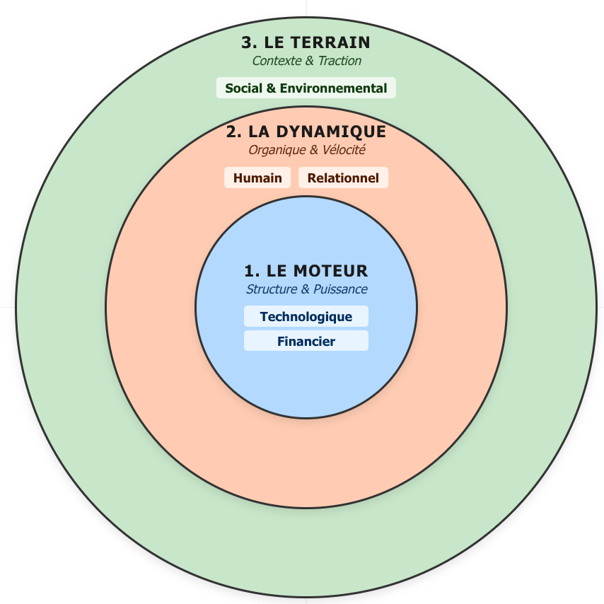

Au centre du modèle se trouve la machine brute. C’est la zone la plus tangible, le domaine du *Hard Power*, où vos décisions technologiques ont l’impact le plus immédiat, mais où les contraintes physiques sont aussi les plus lourdes. Ce cœur bat grâce à deux forces indissociables : le moteur technologique et le carburant financier.

Votre **Capital Technologique** constitue le bloc moteur. C’est votre infrastructure de création de valeur : votre code, vos serveurs, vos données. Sa véritable mesure n’est pas sa taille, mais le ratio entre sa puissance et son poids. D’un côté, vous avez la **Capacité**, cette vélocité brute qui permet de délivrer de nouvelles fonctionnalités ou d’encaisser une charge imprévue le jour du Black Friday. De l’autre, vous traînez l’**Inertie**, ce que nous appelons pudiquement la « dette technique » mais qui est en réalité une dette stratégique. Plus un système est ancien, « fait maison » et interconnecté, plus il résiste au mouvement. Un mainframe des années 90 est peut-être d’une robustesse admirable, mais s’il demande six mois de tests pour modifier une ligne de code, il impose une force de friction colossale à chaque virage. Chaque base de données que vous maintenez artisanalement alors qu’un standard du marché le fait mieux agit comme une ancre sur le bitume.

**L’Erreur Fatale : Confondre Commodité et Différenciation**

L’histoire de **Dell et Asus**[^5] illustre parfaitement le danger de mal diagnostiquer la nature de son Capital Technologique.

À la fin des années 90, Dell, obsédé par l’amélioration de ses ratios financiers (le fameux RONA, *Return on Net Assets*, qui mesure le rendement des actifs possédés par l’entreprise), cherche à se délester de ses actifs les moins rentables. La logique est financièrement irréprochable : pourquoi fabriquer des composants à faible marge quand on peut les sous-traiter ?

Dell confie donc à Asus, un fournisseur taïwanais, la fabrication des circuits, puis de la carte mère, puis de l’assemblage, et finalement du design. À chaque étape, les financiers de Dell applaudissent : le bilan s’allège, la rentabilité des capitaux augmente.

Mais Dell vient de commettre une erreur de diagnostic fatale. En cessant de fabriquer l’artefact, ils ont perdu leur **capacité intégrative** : ils ne savent plus *comment* améliorer le produit. Pendant ce temps, Asus, ayant appris à tout faire, passe du statut de sous-traitant à celui de concurrent redoutable.

Dell croyait avoir abandonné des actifs technologiques commoditaires (fabrication standardisée). En réalité, ils venaient d’abandonner leur « Cœur de Métier » (la maîtrise de l’intégration hardware). Ils ont confondu la rentabilité comptable avec la valeur stratégique.

**L’Arbitrage Inverse : Dropbox et le Retour à la Propriété**

À l’inverse, l’histoire de **Dropbox** montre qu’il n’y a pas de dogme absolu « Build vs Buy ».

À leurs débuts (2008-2015), Dropbox utilise massivement le cloud d’Amazon (AWS S3) pour stocker les fichiers de ses utilisateurs. C’est logique : le stockage est une commodité technique, un composant lourd qu’il vaut mieux louer pour se concentrer sur la différenciation (l’expérience utilisateur, la synchronisation, le partage).

Mais en 2016, Dropbox fait machine arrière et investit massivement pour construire sa propre infrastructure de stockage, le « Magic Pocket ». Pourquoi ?

Pour Dropbox, le stockage a migré du statut « Commodité » vers le statut « Cœur de Métier ». La décision Build vs Buy n’est donc jamais figée : elle dépend de votre échelle, de votre contexte et de votre stratégie de différenciation.

**La leçon pour l’architecte** : Avant de décider de posséder ou de louer un composant technologique, posez-vous la vraie question : « Est-ce que la maîtrise de ce composant me donne un avantage compétitif durable, ou est-ce une distraction qui alourdit mon véhicule ? »

Mais ce moteur ne tourne pas sans énergie. C’est ici qu’intervient votre **Capital Financier**. Pour l’architecte, l’argent n’est pas juste un chiffre au bilan, c’est une matière qui existe sous deux états physiques distincts : le **solide** et le **liquide**.

L’argent **solide** (CAPEX - Capital Expenditure) est celui que vous avez coulé dans le béton de vos data centers, de vos licences perpétuelles, de vos serveurs propriétaires. Il est puissant car il représente une capacité installée, mais rigide : une fois dépensé, il vous lie à des choix passés et vous oblige à rentabiliser l’investissement avant de pouvoir pivoter. C’est comme un réservoir géant fixé au sol : beaucoup de carburant, mais impossible à déplacer.

L’argent **liquide** (OPEX - Operational Expenditure), au contraire, est le carburant de l’adaptation. C’est le budget de fonctionnement qui vous permet de louer des ressources, de tester de nouvelles approches et de pivoter sans être paralysé par les coûts irrécupérables. Un véhicule trop lourd en capital immobilisé est mécaniquement incapable de changer de cap rapidement.

**Exemple**: Considérez deux entreprises qui veulent déployer une infrastructure de calcul intensif pour l’IA. L’entreprise A investit 5M€ en CAPEX pour acheter ses propres serveurs GPU. L’entreprise B utilise le cloud en OPEX pour ~500k€/an. Si la technologie évolue (ce qui arrive tous les 18 mois dans l’IA), l’entreprise A est coincée avec son matériel obsolète et doit choisir entre perdre son investissement ou rester en retard technologique. L’entreprise B, elle, peut passer aux nouvelles générations de GPU dès leur disponibilité, sans coût de transition.

Le passage au Cloud ou au SaaS, souvent réduit à un débat technique, est avant tout une **stratégie de liquidité financière** : vous acceptez de payer votre carburant un peu plus cher au litre, en échange de la liberté de ne plus avoir à traîner la citerne derrière vous.

### Cercle 2 : La dynamique (l’organique)

Un moteur rutilant et un réservoir plein ne servent à rien si personne ne tient le volant, ou si la transmission est cassée. Nous entrons ici dans la couche « vivante » de l’organisation. C’est le cercle de la dynamique, là où la stratégie quitte la théorie pour devenir exécution.

Le premier élément de cette dynamique est le **Pilote**, votre **Capital Humain**. Les rapports financiers refusent obstinément de le faire figurer au bilan (au motif, selon la norme IAS 38 (norme comptable internationale sur les actifs incorporels), que l’entreprise ne « possède » pas ses employés). C’est une cécité comptable dangereuse, car ils sont le système de guidage du véhicule.

Mais attention. Comme le déplorait Henry Ford[^7] : « Pourquoi est-ce que chaque fois que je demande une paire de bras, ils viennent avec un cerveau attaché ? ». Ford voulait des outils. Vous, vous avez besoin de pilotes. Ne confondez pas l’outil et la main qui le tient.

Ainsi, il existe une différence fondamentale entre **l’expertise d’un outil** (savoir coder en COBOL, configurer un routeur Cisco spécifique, administrer Oracle 11g) et le **potentiel d’adaptation** (savoir résoudre un problème complexe, apprendre rapidement, comprendre le métier).

L’expertise outil est un actif **périssable**, voire toxique. Si la technologie meurt, l’expert devient un frein : il résistera inconsciemment au changement pour protéger son statut, sa zone de confort et sa valeur perçue. C’est l’inertie humaine la plus violente, car elle touche à l’identité.

À l’inverse, le véritable capital réside dans la **capacité de vos équipes à se détacher de leurs outils fétiches pour embrasser la mission**. Un développeur qui se définit comme « résolveur de problèmes métier X » plutôt que « Expert Java » est un actif durable. Son expertise architecturale sur Java enrichira son approche sur Python, Go ou Rust demain.

**Exemple - Microsoft et la transformation Cloud (2014-2020)**: Lorsque Satya Nadella prend la tête de Microsoft en 2014, l’entreprise possède des milliers d’ingénieurs experts Windows Server, experts .NET Framework on-premise, experts licensing perpétuel. Le pivot stratégique vers Azure (cloud) et vers l’open-source menace directement leur expertise historique.

Le capital humain de Microsoft aurait pu devenir une masse d’inertie catastrophique. Au lieu de cela, Nadella lance un programme massif de requalification (« reskilling ») : les experts Windows Server deviennent experts Azure, les évangélistes .NET apprennent Linux et Kubernetes, les vendeurs de licences perpétuelles apprennent à vendre des abonnements.

Ce qui a fait la différence ? Nadella n’a pas recruté massivement de nouveaux profils. Il a parié sur le **potentiel d’apprentissage** de ses équipes existantes, en leur offrant une nouvelle mission (« *Cloud First* ») plutôt qu’un nouvel outil. Résultat : Azure devient le deuxième cloud mondial, et Microsoft retrouve sa capacité d’innovation.

Cette transformation n’a pas été indolore. Plus de 25 000 postes ont été supprimés dans les divisions Windows Phone et Nokia entre 2014 et 2016[^8].

Le cas d’Oracle illustre un autre visage de l’inertie. Ce n’est pas la résistance des ingénieurs qui a paralysé la transition vers le cloud, mais le choix délibéré de la direction (Larry Ellison qualifiait le cloud de « charabia complet » en 2008) de protéger les marges colossales du modèle de licences *on-premise*[^9]. Oracle a laissé plusieurs années d’avance à AWS et Azure, victime non pas de l’inertie humaine, mais de l’inertie financière : le refus de cannibaliser sa propre vache à lait.

Cependant, les meilleurs pilotes sont impuissants si les commandes ne répondent pas. C’est le rôle de la **Transmission**, votre **Capital Relationnel**. C’est le système nerveux de l’organisation, l’huile dans les rouages qui permet à l’information de circuler et aux décisions de se transformer en actions.

Sa **capacité** se mesure en une unité simple mais rare : **la confiance**. Une équipe dont la « batterie de confiance » est chargée communique à demi-mot, prend des décisions décentralisées et exécute vite. Les membres se font mutuellement confiance pour tenir leurs engagements sans nécessiter de contrôle constant.

À l’inverse, l’**inertie** se manifeste ici par les frottements politiques, les silos étanches et les guerres de territoire. Si une décision technique validée met trois semaines à traverser l’organisation, passe par quatre comités et nécessite douze signatures avant d’être appliquée, votre transmission est grippée. L’énergie du moteur, au lieu de se transformer en mouvement, se dissipe en chaleur conflictuelle.

**Exemple - Spotify et l’architecture « Squads » (2012-2018)**: Face à sa croissance explosive (de 20 à 2000+ employés en quelques années), Spotify refuse le modèle traditionnel en silos (Devs / Ops / Product / Marketing séparés). Ils créent des « Squads » : équipes autonomes de 6-12 personnes possédant toutes les compétences nécessaires pour livrer une fonctionnalité de bout en bout.

Chaque Squad a l’autonomie décisionnelle sur son périmètre. Pas de validation hiérarchique pour chaque décision technique. La confiance est le principe de base : *« We trust our teams to make the right decisions. »*[^10]

Le Capital Relationnel de Spotify devient un **actif de vélocité** : le temps entre « décision prise » et « code en production » se mesure en heures, pas en semaines. Pas de silos à traverser, pas de comités à convaincre, pas de baronies à ménager.

L’exemple inverse ? Les grandes banques où une simple modification d’API doit passer par le Comité Architecture, le Comité Sécurité, le Comité Risque, la Validation PMO, et la Direction Informatique. Résultat : 6 mois pour une modification qui prend 2 jours à coder. Le Capital Relationnel structuré en silos agit comme un multiplicateur d’inertie.

### Cercle 3 : Le terrain (le contexte)

Enfin, n’oubliez jamais que votre véhicule ne se déplace pas dans le vide. Il roule sur une route publique, régie par la société, les lois et les limites planétaires. Ce troisième cercle est souvent négligé par les technologues, considérant ces sujets comme « périphériques » ou « hors périmètre IT », jusqu’au jour où la route se ferme brutalement devant eux.

C’est ici que se joue votre **Permis de Conduire**, votre légitimité à opérer. Ce n’est pas une question de morale ou de philanthropie corporate, c’est une condition physique de mouvement. Votre **Capital Social et Environnemental** détermine si le terrain acceptera votre passage ou vous bloquera.

Ce capital possède deux dimensions interconnectées :

**La dimension réputationnelle** : C’est votre « soft power », votre influence et la confiance que vous inspirez. En interne, c’est votre crédit pour proposer des transformations risquées sans déclencher de résistance immunitaire. En externe, c’est votre capacité à attirer les talents, à convaincre les partenaires et à définir les standards du marché.

L’**inertie réputationnelle** est insidieuse : une fois étiqueté (ex: « l’entreprise des mainframes »), il devient coûteux de changer cette perception. Kodak, même après avoir inventé l’appareil photo numérique en 1975[^11], n’a jamais été perçue comme légitime sur ce terrain. La réputation peut devenir une prison dorée.

**La dimension environnementale et sociale** : En 2025, l’impact ESG (Environmental, Social, Governance) n’est plus une option cosmétique pour rapport annuel, c’est un **actif stratégique**[^12]. Il conditionne l’accès aux talents (les profils qualifiés, notamment tech, privilégient massivement les entreprises à impact positif), l’accès au financement (les critères ESG pèsent de plus en plus sur les décisions d’investissement et de prêt), l’accès au marché (les réglementations comme la CSRD (Corporate Sustainability Reporting Directive) en Europe deviennent des barrières à l’entrée) et la résilience opérationnelle (anticiper les contraintes carbone, c’est éviter les disruptions futures).

Mais ce capital comporte aussi une **inertie environnementale** massive : votre empreinte carbone devient une **dette invisible** qui se transforme en passif stratégique. Vos data centers propriétaires, vos serveurs obsolètes à haute consommation énergétique, votre infrastructure legacy inefficiente constituent une dette carbone croissante. Une infrastructure qui n’anticipe pas la transition énergétique devient un fardeau réglementaire, et les normes de reporting carbone, les taxes et quotas se transforment en Coûts de Portage massifs.

**Exemple - La stratégie cloud comme décarbonation (2020-2025)**: Migrer vers le Cloud n’est pas qu’une stratégie de coûts ou de flexibilité. C’est aussi, de plus en plus, une stratégie de **décarbonation**. Les hyperscalers (AWS, Azure, Google Cloud) optimisent leur consommation énergétique et leur mix énergétique (renouvelables) bien mieux qu’un data center d’entreprise traditionnel.

Un data center d’entreprise typique gaspille une grande part de son énergie dans le refroidissement, affichant un PUE (*Power Usage Effectiveness*) moyen de 1,6 à 2,0. En comparaison, un data center hyperscaler optimisé atteint une efficacité quasi parfaite avec un PUE proche de 1,1[^13]. Résultat : migrer vers le cloud réduit significativement votre empreinte carbone IT, transformant un passif environnemental en argument de conformité réglementaire.

L’exemple inverse ? Les entreprises qui, par « souveraineté des données » ou par inertie, maintiennent des data centers obsolètes et inefficaces. Elles se retrouvent confrontées à des taxes carbone croissantes, à des difficultés de recrutement (les jeunes talents refusent de travailler pour des « pollueurs »), et à des exclusions d’appels d’offres publics exigeant des critères ESG.

Choisir des technologies sobres aujourd’hui, ce n’est pas une « bonne action » RSE. C’est la seule manœuvre rationnelle pour s’assurer que vous aurez encore le droit de rouler dans cinq ans.

L’inventaire révèle une vérité inconfortable : la richesse apparente (posséder beaucoup de technologie, beaucoup de talents, beaucoup de processus) ne garantit pas la puissance réelle.

## Conclusion : la règle de l’architecte

Nous avons refermé le capot. L’inventaire de votre véhicule est terminé et il révèle une double réalité que le bilan comptable ne saura jamais capturer.

Votre organisation est une chimère. Elle est constituée d’**Actifs de valeur** (vos flux d’énergie, vos potentiels humains, votre réputation) qui forment votre moteur. Mais elle traîne aussi, inévitablement, une masse d’**Artefacts** (ce code legacy dont vous êtes si fiers, ces serveurs que vous possédez, ces processus rassurants) qui génèrent votre inertie.

Le véritable travail de l’architecte commence dans ce changement de regard radical. Il ne s’agit plus de tomber amoureux de ce que vous avez construit, ni de mesurer votre réussite à la taille de votre patrimoine technologique. Il s’agit d’accepter une vérité brutale : **tout actif est temporaire.**

Ce code qui fait votre fierté aujourd’hui est la dette technique de demain. Cette compétence rare que vous vous arrachez deviendra une commodité banale dans trois ans. Ce n’est pas un échec de gestion, c’est une loi de la nature économique. Vous ne pouvez pas empêcher ce vieillissement, pas plus que vous ne pouvez empêcher la gravité.

Face à cette réalité, votre doctrine stratégique doit tenir en une phrase d’une simplicité impitoyable : **Maximisez la Capacité Stratégique, minimisez le Coût de Portage.**

Autrement dit : gardez ce qui vous propulse, jetez ce qui vous alourdit.

La manière dont vous gérez ces capitaux dépend directement de votre maturité doctrinale (celle que nous avons diagnostiquée au chapitre précédent). Avoir des capitaux abondants sans doctrine mature, c’est un moteur V12 avec un conducteur débutant : vous allez dans le mur. Avoir une doctrine mature sans capitaux, c’est un pilote d’élite sans véhicule : vous restez sur place. L’art de l’architecte est de faire croître les deux en parallèle.

### Le pont vers l’évolution

Mais cette règle (*Maximiser la Capacité, Minimiser l’Inertie*) soulève une question vertigineuse : si vos actifs perdent inévitablement leur caractère unique pour devenir des standards banalisés, **quand** faut-il agir ? Comment savoir, avec précision, à quel moment jeter ce qui était hier votre avantage concurrentiel ?

Pour répondre, il faut comprendre la **mécanique de l’évolution elle-même** : cette force extérieure, universelle et irrésistible qui pousse inlassablement tout ce qui existe (vos technologies, vos pratiques, vos modèles économiques) vers la banalisation. Elle suit des lois précises, prévisibles et exploitables. Comme la glace qui absorbe une quantité phénoménale d’énergie avant de changer d’état, les systèmes économiques résistent aux transformations selon des patterns identifiables. Comprendre ces patterns, c’est gagner le pouvoir d’anticiper.

L’inertie n’est pas seulement une résistance humaine ou organisationnelle. C’est une force de la nature. Arrêtons de la subir. Apprenons à l’utiliser.

**C’est l’objet de la Partie III : Les Lois du Mouvement.**

v2.16.0-beta